# Lecture4

September 28, 2019

## Принципи візуалізації даних і попереднього аналізу

Набір пакетів tidyverse

```r
library(tidyverse)
```

## Набір даних про машини

```r
str(mpg)
```

```
## Classes 'tbl_df', 'tbl' and 'data.frame':    234 obs. of  11 variables:
##  $ manufacturer: chr  "audi" "audi" "audi" "audi" ...
##  $ model       : chr  "a4" "a4" "a4" "a4" ...
##  $ displ       : num  1.8 1.8 2 2 2.8 2.8 3.1 1.8 1.8 2 ...
##  $ year        : int  1999 1999 2008 2008 1999 1999 2008 1999 1999 2008 ...
##  $ cyl         : int  4 4 4 4 6 6 6 4 4 4 ...
##  $ trans       : chr  "auto(l5)" "manual(m5)" "manual(m6)" "auto(av)" ...
##  $ drv         : chr  "f" "f" "f" "f" ...
##  $ cty         : int  18 21 20 21 16 18 18 18 16 20 ...
##  $ hwy         : int  29 29 31 30 26 26 27 26 25 28 ...
##  $ fl          : chr  "p" "p" "p" "p" ...
##  $ class       : chr  "compact" "compact" "compact" "compact" ...
```

```r
head(mpg)
```

```
## # A tibble: 6 x 11
##   manufacturer model displ  year   cyl trans  drv     cty   hwy fl    class
##   <chr>        <chr> <dbl> <int> <int> <chr>  <chr> <int> <int> <chr> <chr>
## 1 audi         a4      1.8  1999     4 auto(… f        18    29 p     comp…
## 2 audi         a4      1.8  1999     4 manua… f        21    29 p     comp…
## 3 audi         a4      2    2008     4 manua… f        20    31 p     comp…
## 4 audi         a4      2    2008     4 auto(… f        21    30 p     comp…
## 5 audi         a4      2.8  1999     6 auto(… f        16    26 p     comp…
## 6 audi         a4      2.8  1999     6 manua… f        18    26 p     comp…
```

## Попередня візуалізація

```r
ggplot(data = mpg) + geom_point(mapping = aes(x = displ, y = hwy))
```

## Було б цікаво візуалізувати типи машин і інші параметри

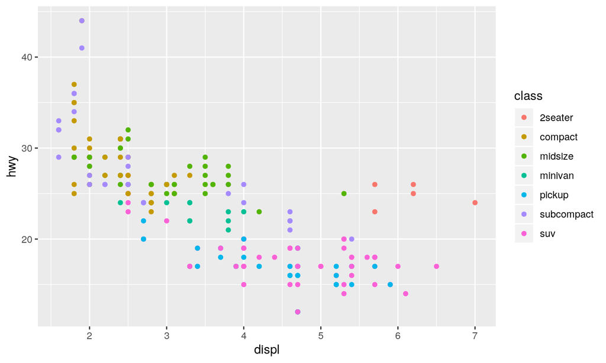

```r
ggplot(data = mpg) + geom_point(mapping = aes(x = displ, y = hwy, color = class))
```

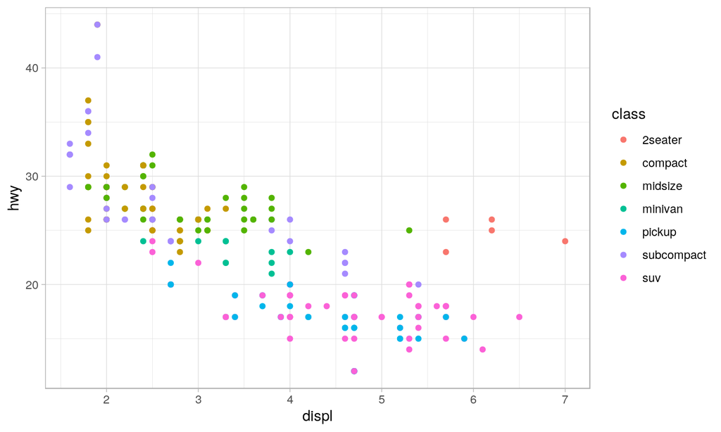

```r
ggplot(data = mpg) + geom_point(mapping = aes(x = displ, y = hwy, color = class)) +
  theme_light()
```

## Ще можливості

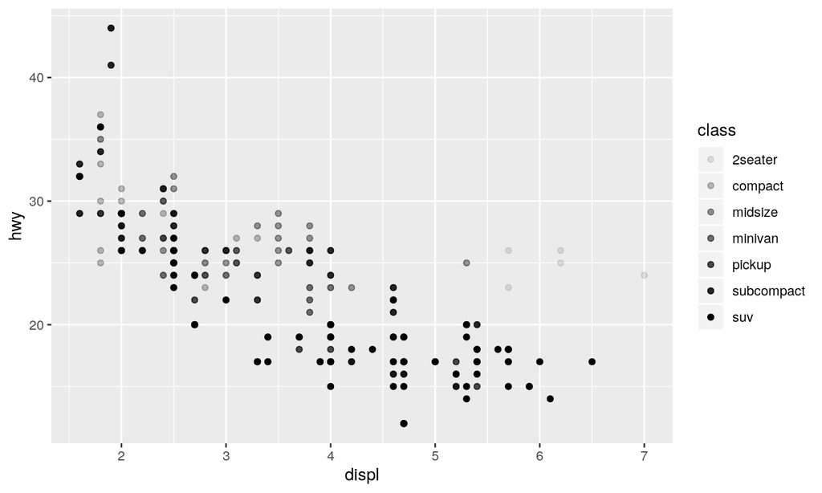

```r
ggplot(data = mpg) +
geom_point(mapping = aes(x = displ, y = hwy, alpha = class))
```

## І ще

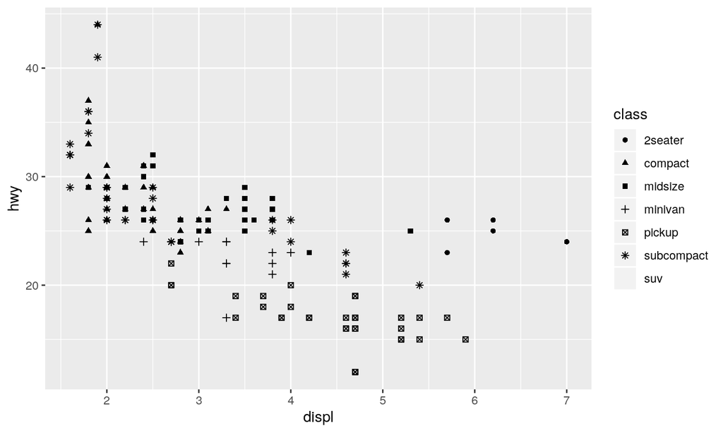

```r
ggplot(data = mpg) +
geom_point(mapping = aes(x = displ, y = hwy, shape = class))
```

## Завдання. Що не так з цим кодом?

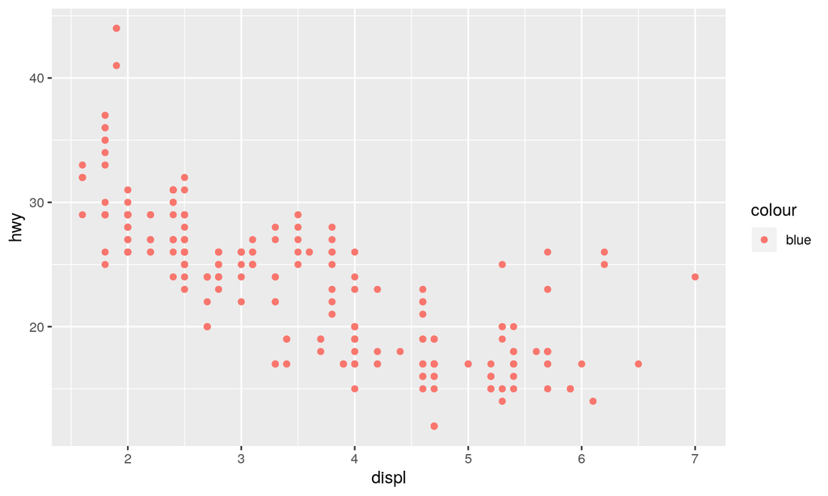

```r
ggplot(data = mpg) +
geom_point(
mapping = aes(x = displ, y = hwy, color = "blue")
)
```

## Загальний шаблон

Пакет дозволяє створювати графіки пошарово (і ви можете гнучко керувати процесом ан кожному етапі) Всі графіки складаються з

- Даних
- Шарів
- Естетики (які змінні використовувати)
- Координатної системи
- Фасеток
- Теми

## Завдання для розігріву.

В даному датасеті дані американські - cty city miles per gallon - hwy highway miles per gallon

Як перевести галони і милі в кілометри і літри? За допомогою dplyr!

## Відповідь

```r
mpg2 <- mpg %>%
  mutate(cty2 = cty * 1.609344 / 3.78541178,
         hwy2 = hwy * 1.609344 / 3.78541178)
```

## Приклад фасеток

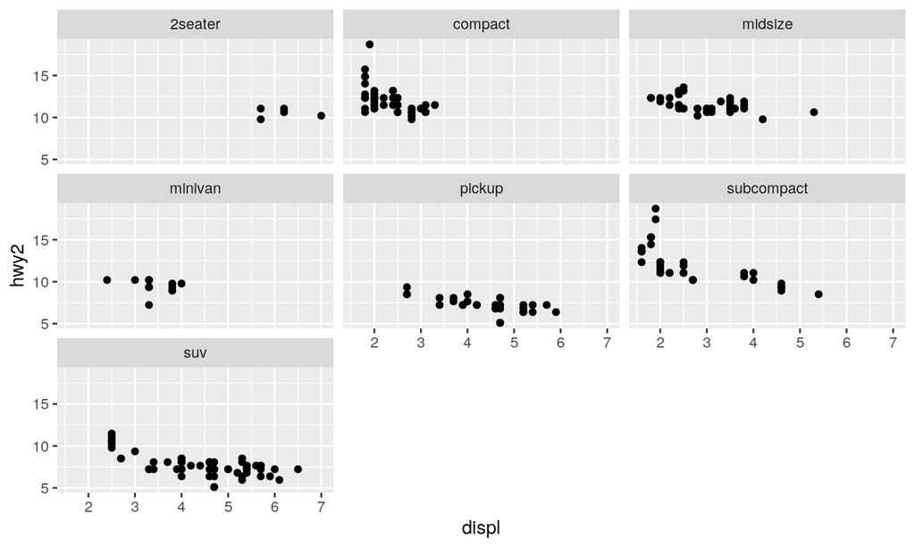

```r
ggplot(mpg2, aes(displ, hwy2)) +
geom_point() +
facet_wrap(~class)
```

## Найбільш вживані геоми

- geom_smooth() додає регресію (заданого порядку) і додає його стандартну похибку
- geom_boxplot() створює box-and-whisker графік для візуалізації статистичних параметрів
- geom_histogram() та geom_freqpoly() показує розподіл неперервних змінних
- geom_bar() показує розподіл категоріальних змінних
- geom_path() та geom_line() з'єднують лініями точки. Лінії можуть йти лише з ліва на право, а шляхи як завгодно.

Давайте спробуємо зробити по графіку кожного типу.

## Регресія

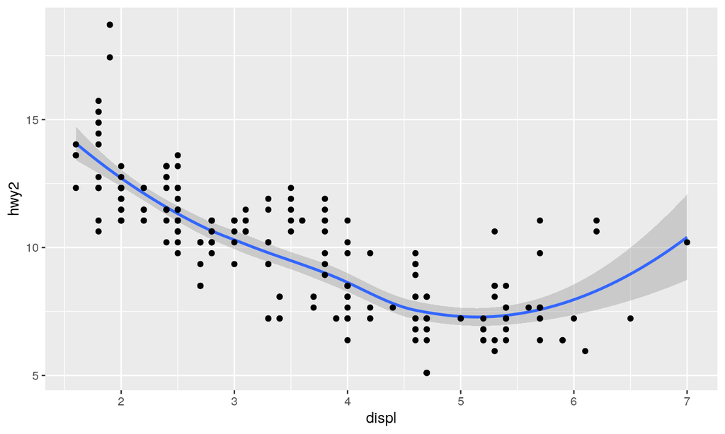

```r
ggplot(data = mpg2,aes(displ, hwy2)) +
  geom_smooth() +
  geom_point()
```

## Є багато різних можливостей

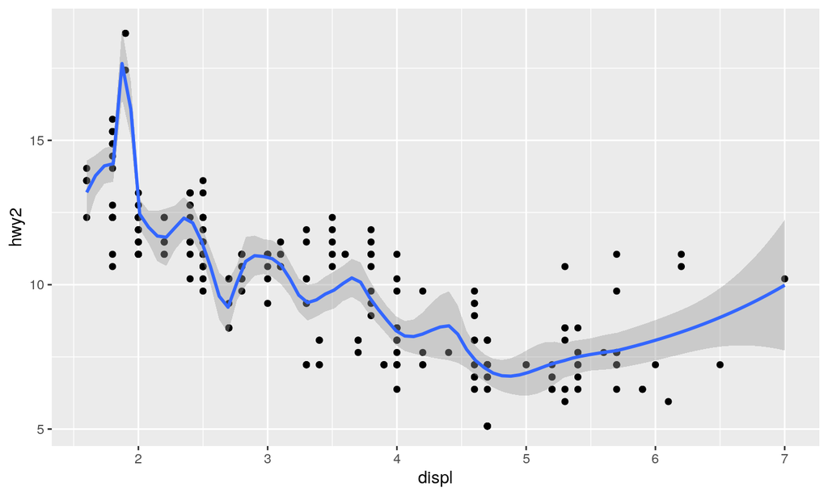

```r
ggplot(mpg2, aes(displ, hwy2)) +
geom_point() +
geom_smooth(span = 0.2)
```

## Лінійна регресія

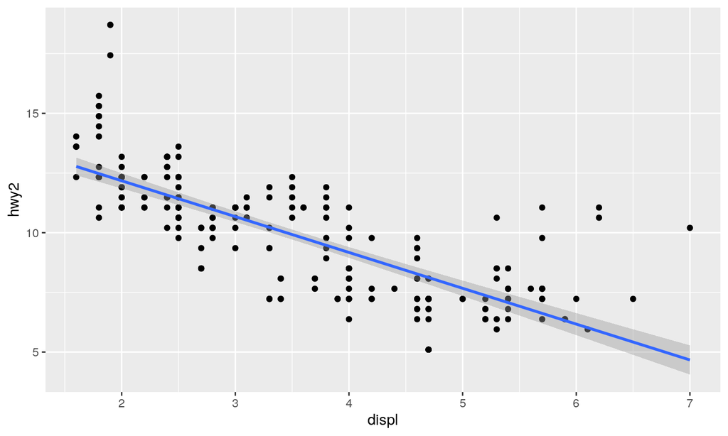

```r
ggplot(mpg2, aes(displ, hwy2)) +
geom_point() +
geom_smooth(method = "lm")
```

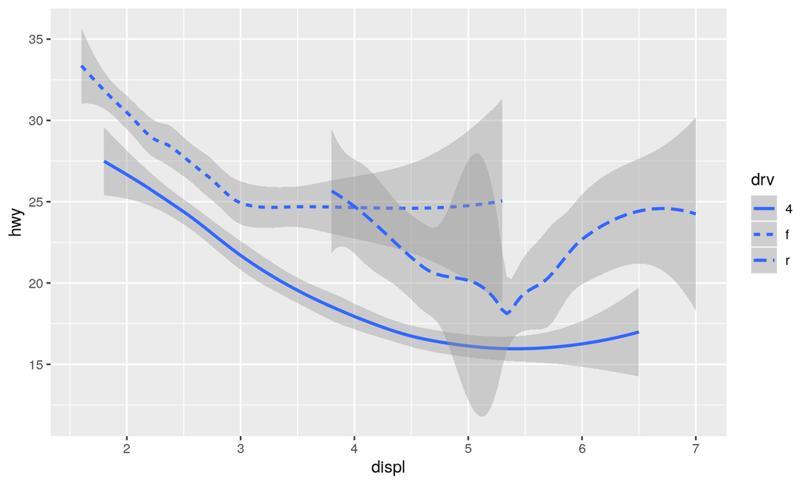

```r
ggplot(data = mpg) +
geom_smooth(mapping = aes(x = displ, y = hwy,linetype = drv))
```

## Boxplot

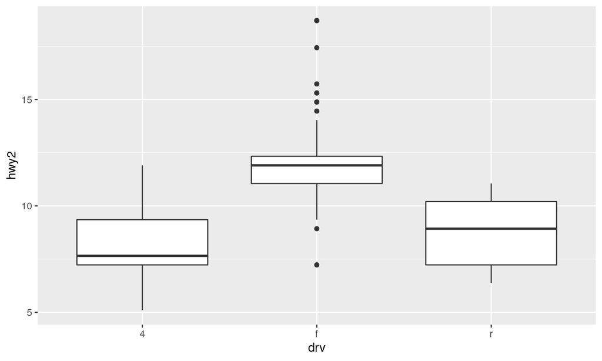

```r
ggplot(data = mpg2,aes(drv, hwy2)) +
  geom_boxplot()
```

## Інші приклади

```r
ggplot(mpg, aes(drv, hwy)) + geom_jitter()
ggplot(mpg, aes(drv, hwy)) + geom_boxplot()
ggplot(mpg, aes(drv, hwy)) + geom_violin()
```

## Гістограма

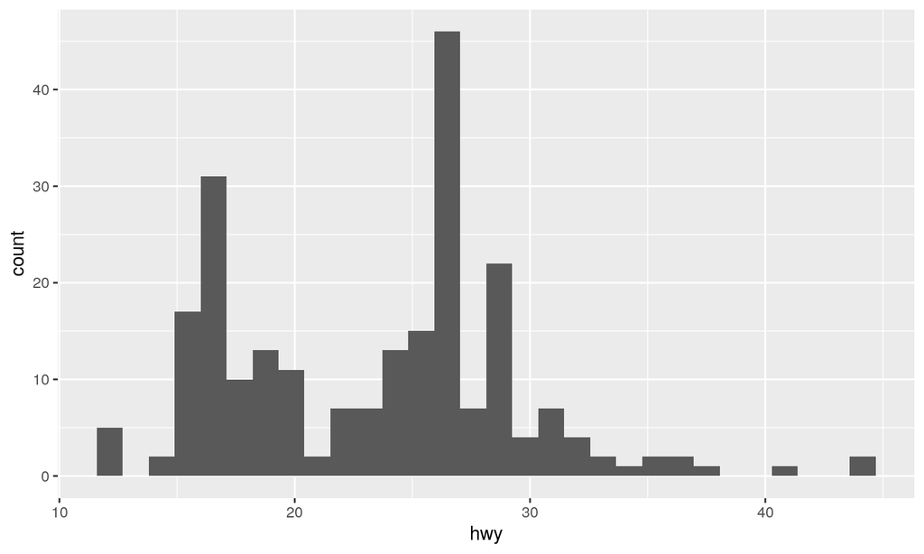

```r
ggplot(mpg, aes(hwy)) + geom_histogram()
```

## Стовпчикова діаграма

```r
ggplot(mpg, aes(manufacturer)) +
geom_bar()
```

## Всі геоми 1

1. **geom_abline** alpha, color, fill, linetype, size
2. **geom_area** x, ymax (ymin fix to 0) alpha, color, fill, linetype, size
3. **geom_bar** x alpha, color, fill, linetype, size, weight
4. **geom_boxplot** lower, middle, upper, ymax, ymin x, alpha, color, fill, linetype, shape, size, weight
5. **geom_density** x, y alpha, color, fill, linetype, size, weight
6. **geom_dotplot** x, y alpha, color, fill
7. **geom_histogram** x alpha, color, fill, linetype, size, weight
8. **geom_hline** alpha, color, linetype, size

## Всі геоми 2

1. **geom_jitter** x, y alpha, color, fill, shape, size
2. **geom_line** x, y alpha, color, linetype, size
3. **geom_point** x, y alpha, color, fill, shape, size
4. **geom_ribbon** x, ymax, ymin alpha, color, fill, linetype, size
5. **geom_smooth** x, y alpha, color, fill, linetype, size, weight
6. **geom_text** label, x, y alpha, angle, color, family, fontface, hjust, lineheight, size, vjust

## Приклад цікавої неочевидної візуалізації

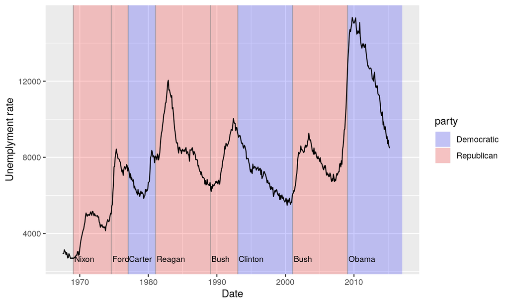

## Для розуміння структури пакету пройдемось по граматиці

```r
ggplot(mpg, aes(displ, hwy, colour = cyl)) +
geom_point()
ggplot(mpg, aes(displ, hwy, colour = factor(cyl))) +
geom_point()
```

## Більш складний приклад

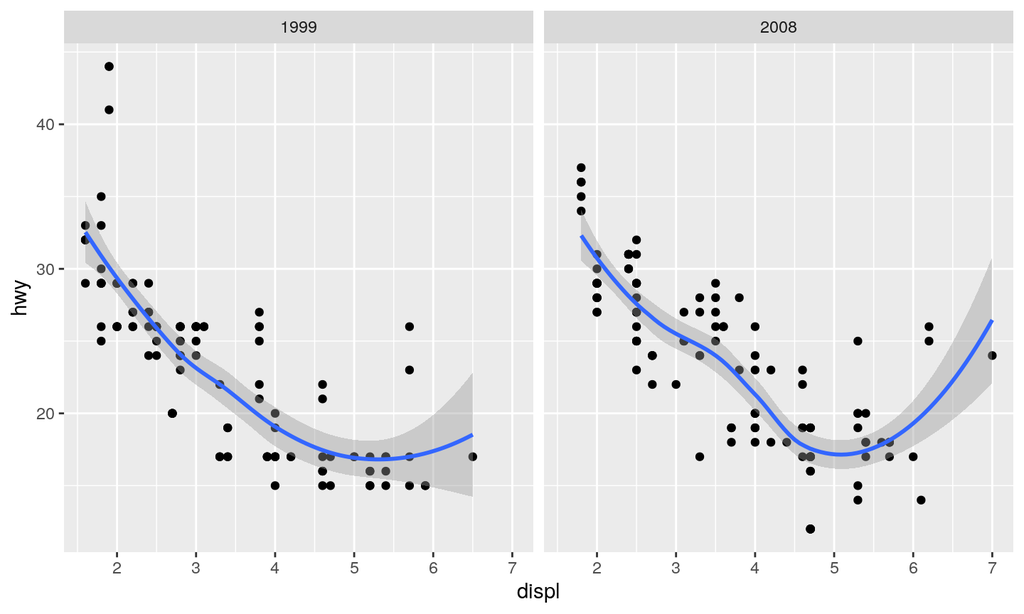

```r
ggplot(mpg, aes(displ, hwy)) +
geom_point() +
geom_smooth() +
facet_wrap(~year)
```

## Будуємо графік шар за шаром

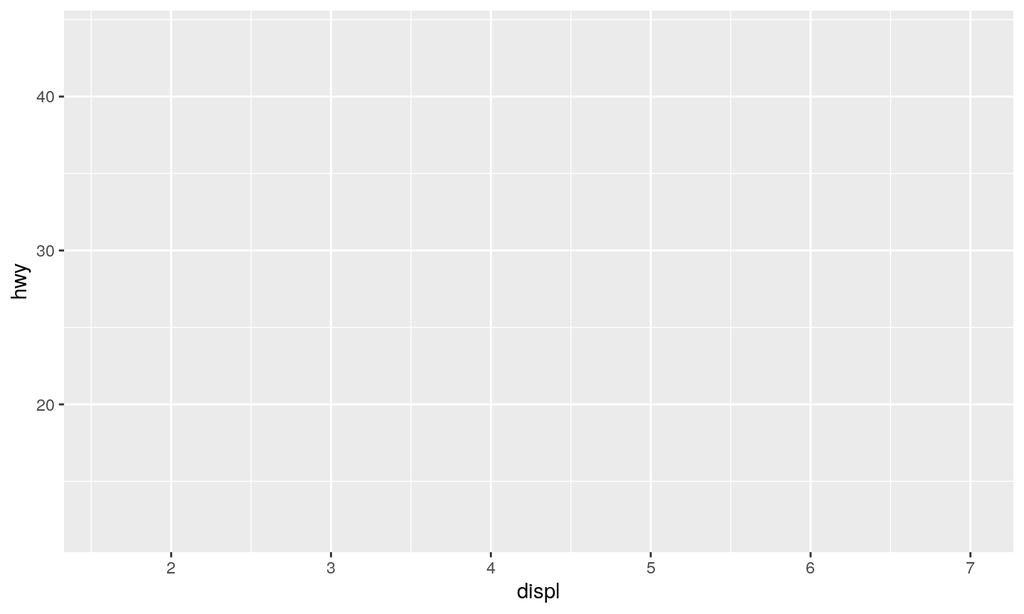

```r
p <- ggplot(mpg, aes(displ, hwy))
p
```

## Додамо геом - точки

```r
p + geom_point()
```

## Geom_point() це скорочення функції layer()

```r
p + layer(
        mapping = NULL,
        data = NULL,
        geom = "point",
        stat = "identity",
        position = "identity"
          )
```

## Головні елементи кожного шару

- mapping: відображення, множина естетик, визначена функцією aes().
- data: дані, які можуть переписати початковий датасет графіка.
- geom: назва геометричного об'єкту, який використовується для прорисовки кожного виміру. Геом може мати додаткові аргументи.
- stat: назва статистичного перетворення даних. Результат зображається на графіку.
- position: розташування, використовується для роботи з об'єктами, які накладаються.

## Додамо вручну регресію

```r
mod <- loess(hwy ~ displ, data = mpg)
grid <- data_frame(displ = seq(min(mpg$displ), max(mpg$displ), length = 50))
grid$hwy <- predict(mod, newdata = grid)
grid
```

```
## # A tibble: 50 x 2
##    displ   hwy
##    <dbl> <dbl>
##  1  1.6   33.1
##  2  1.71  32.2
##  3  1.82  31.3
##  4  1.93  30.4
##  5  2.04  29.6
##  6  2.15  28.8
##  7  2.26  28.1
##  8  2.37  27.4
##  9  2.48  26.7
## 10  2.59  26.1
## # … with 40 more rows
```

## Далі відкинемо занадто далекі точки

```r
std_resid <- resid(mod) / mod$s
outlier <- filter(mpg, abs(std_resid) > 2)
outlier
```

```
## # A tibble: 6 x 11
##   manufacturer model  displ  year   cyl trans drv     cty   hwy fl    class
##   <chr>        <chr>  <dbl> <int> <int> <chr> <chr> <int> <int> <chr> <chr>
## 1 chevrolet    corve…   5.7  1999     8 manu… r        16    26 p     2sea…
## 2 pontiac      grand…   3.8  2008     6 auto… f        18    28 r     mids…
## 3 pontiac      grand…   5.3  2008     8 auto… f        16    25 p     mids…
## 4 volkswagen   jetta    1.9  1999     4 manu… f        33    44 d     comp…
## 5 volkswagen   new b…   1.9  1999     4 manu… f        35    44 d     subc…
## 6 volkswagen   new b…   1.9  1999     4 auto… f        29    41 d     subc…
```

## Тепер додамо лінію на графік

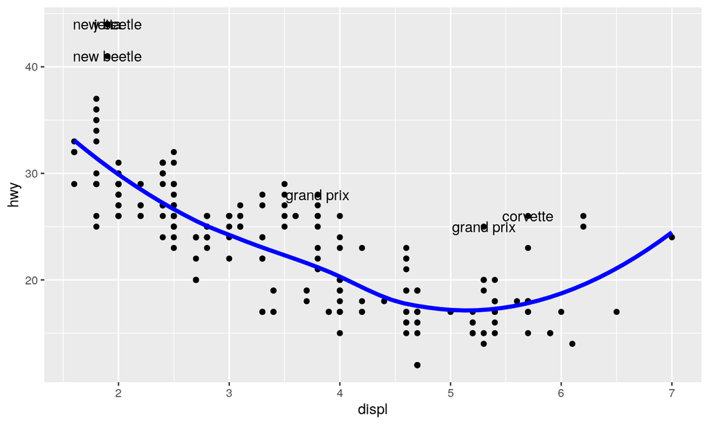

```r
ggplot(mpg, aes(displ, hwy)) +
geom_point() +
geom_line(data = grid, colour = "blue", size = 1.5) +
geom_text(data = outlier, aes(label = model))
```

## Також можливо визначити датасет для кожного шару окремо

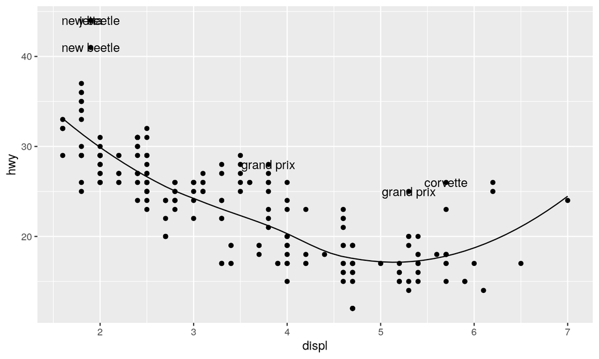

```r
ggplot(mapping = aes(displ, hwy)) +
geom_point(data = mpg) +
geom_line(data = grid) +
geom_text(data = outlier, aes(label = model))
```

## Завдання.

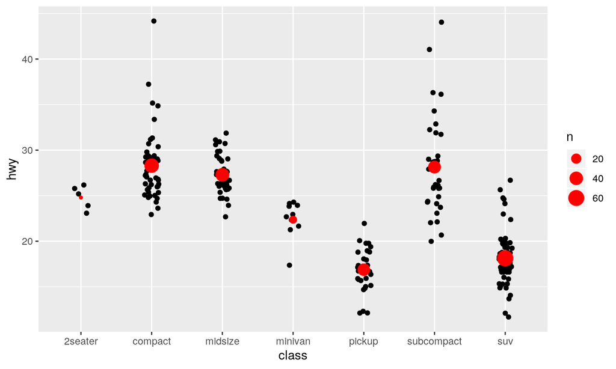

## Можна використовувати функції dplyr

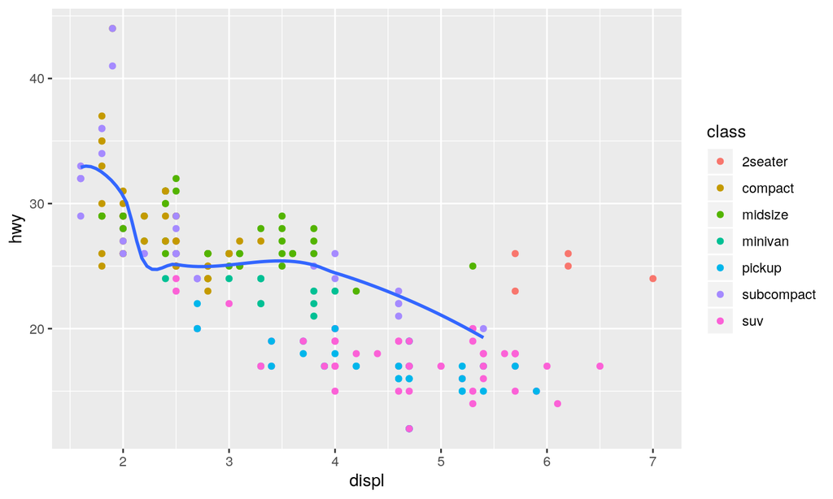

```r
ggplot(data = mpg, mapping = aes(x = displ, y = hwy)) +
geom_point(mapping = aes(color = class)) +
geom_smooth(
            data = filter(mpg, class == "subcompact"),
            se = FALSE
            )
```

## Статистичні перетворення

```r
ggplot(data = mpg) +
geom_bar(mapping = aes(x = manufacturer))
```

## Створення нової змінної

```r
ggplot(data = mpg) +
stat_count(mapping = aes(x = manufacturer))
```

## Навіщо? Більша гнучкість, можна. наприклад, перевантажувати операції за замовчуванням

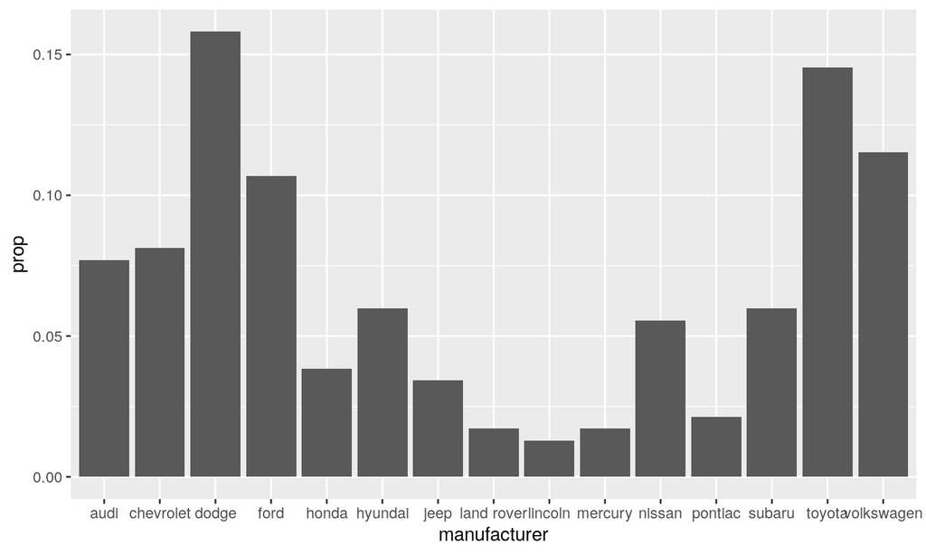

```r
ggplot(data = mpg) +
geom_bar(
mapping = aes(x = manufacturer, y = ..prop.., group = 1)
)
```

## Зі статистичними перетвореннями можливостей ще більше

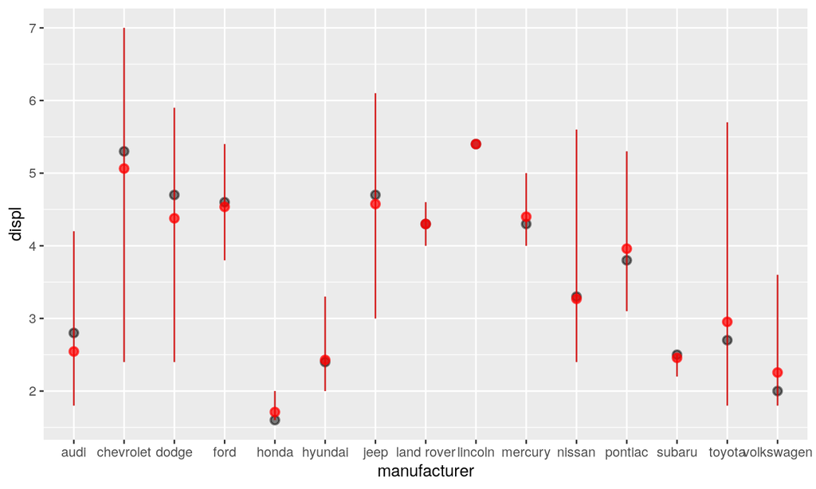

```r
ggplot(data = mpg) +
stat_summary(
            mapping = aes(x = manufacturer, y = displ),
            fun.ymin = min,
            fun.ymax = max,
            fun.y = median,
            alpha = 0.5
              ) +
stat_summary(
            mapping = aes(x = manufacturer, y = displ),
            fun.ymin = min,
            fun.ymax = max,
            fun.y = mean,
            color = "red",
            alpha = 0.7
              )
```

## Налаштування позиції.

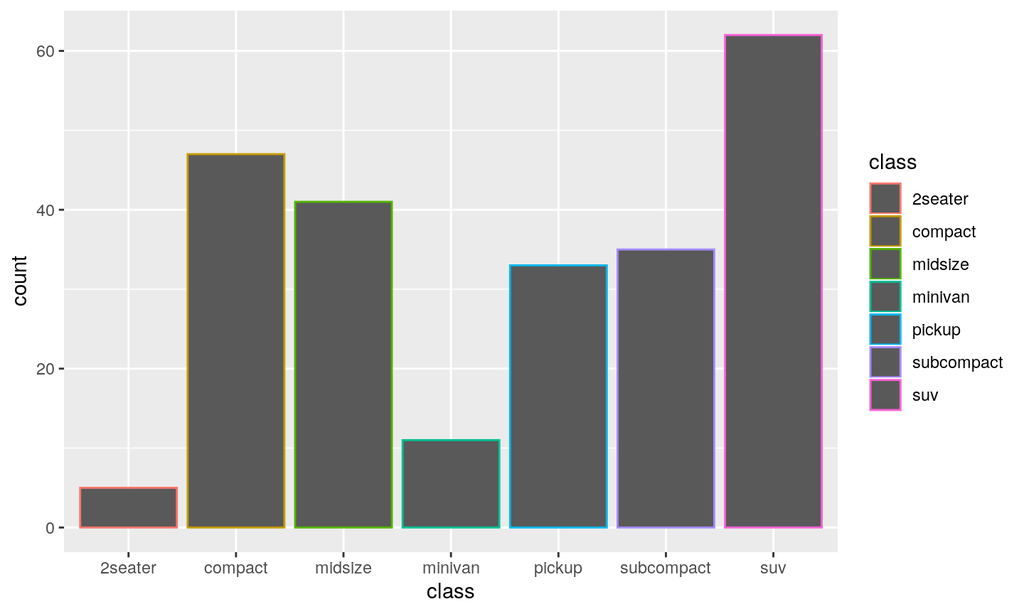

```r
ggplot(data = mpg) +
geom_bar(mapping = aes(x = class, color = class))
```

## Як тільки ми додамо іншу змінну

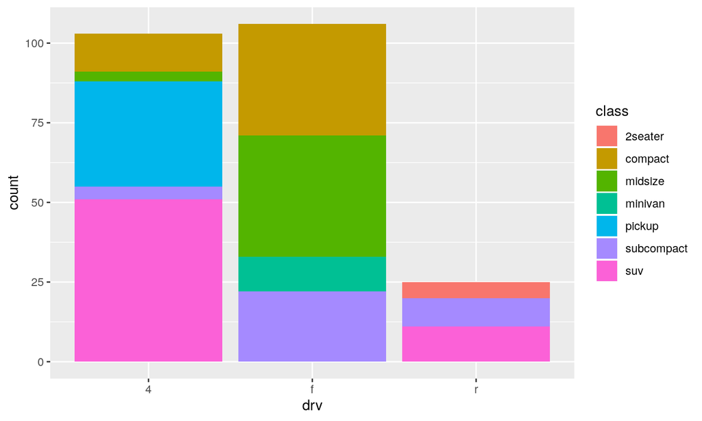

```r
ggplot(data = mpg) +
geom_bar(mapping = aes(x = drv, fill = class))
```

## Це стакінг - тобто складання.

Якщо ми не хочемо такого, треба вказати це явно

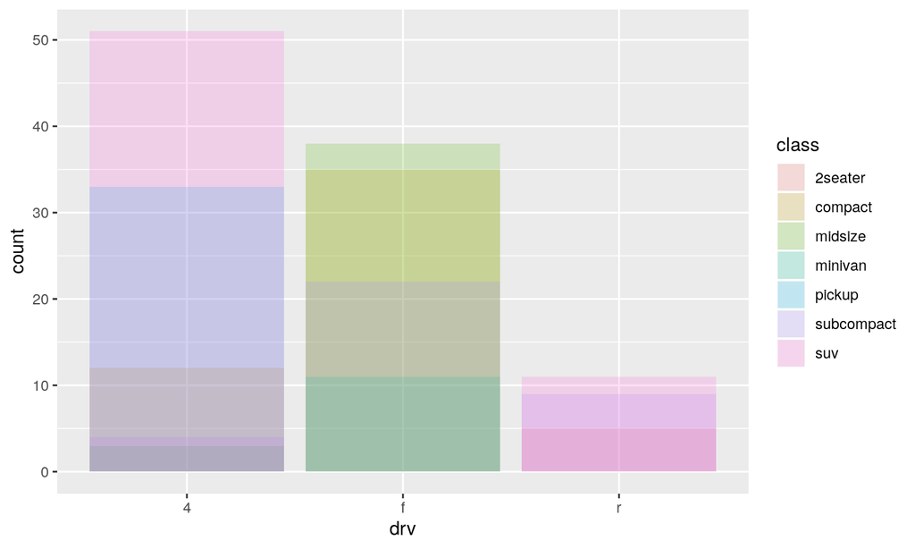

```r
ggplot(data = mpg) +
geom_bar(mapping = aes(x = drv, fill = class), alpha = 1/5, position = "identity")
```

## Це стакінг - тобто складання.

Якщо ми не хочемо такого, треба вказати це явно

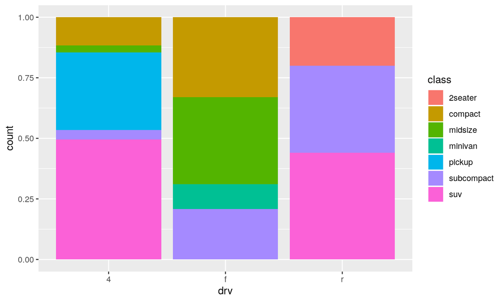

```r
ggplot(data = mpg) +
geom_bar(mapping = aes(x = drv, fill = class), position = "fill")
```

## Це стакінг - тобто складання.

Якщо ми не хочемо такого, треба вказати це явно

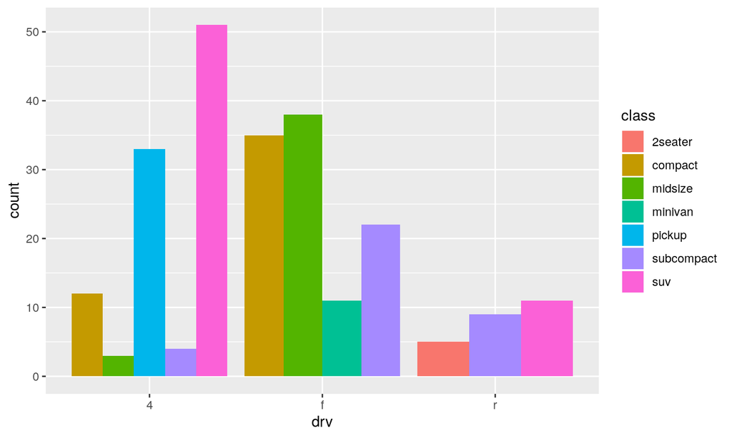

```r
ggplot(data = mpg) +
geom_bar(mapping = aes(x = drv, fill = class), position = "dodge")
```

## Трансформації координат

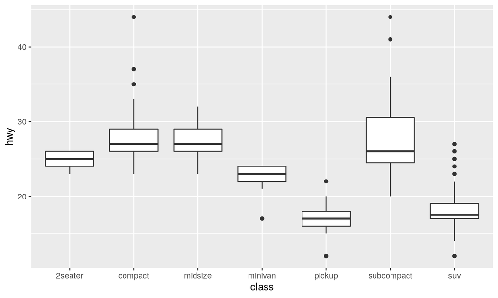

```r
ggplot(data = mpg, mapping = aes(x = class, y = hwy)) +
geom_boxplot()
```

## Трансформації координат

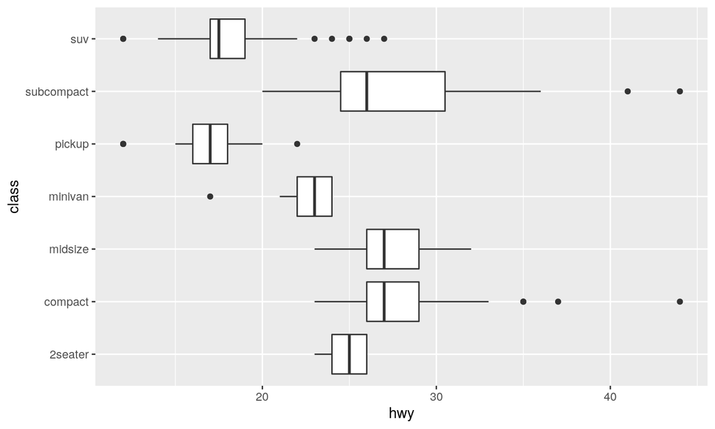

```r
ggplot(data = mpg, mapping = aes(x = class, y = hwy)) +
geom_boxplot() +
coord_flip()
```

## Розмір пропорційний кількості

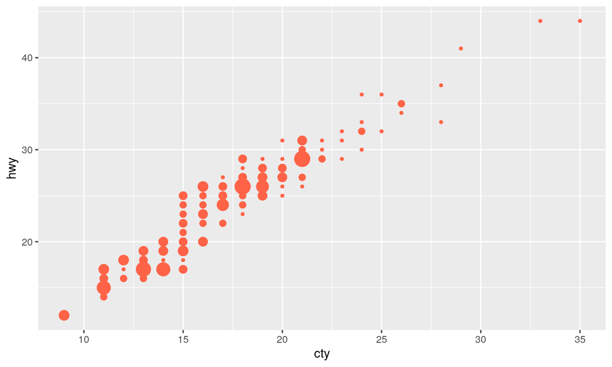

```r
ggplot(mpg, aes(cty, hwy)) + geom_count(col="tomato", show.legend=F)
```

## Країни світу

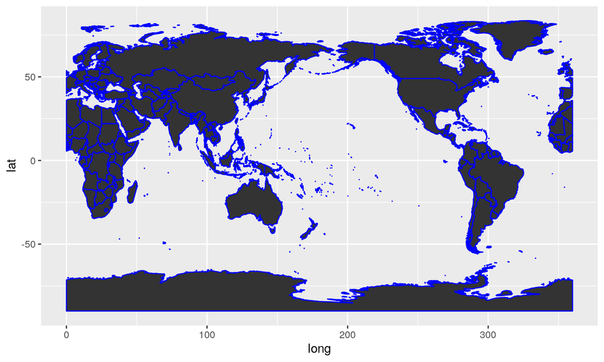

```r
library(maps)
library(ggplot2)

world_map <- map_data("world2")
ggplot(world_map, aes(x=long, y=lat, group=group)) +geom_polygon(colour="blue") + scale_fill_brewer(palette="Set2")
```

## Азія

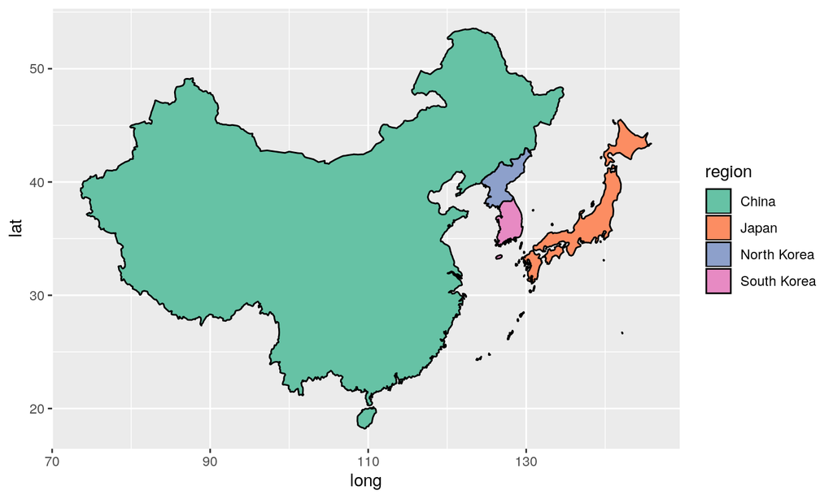

```r
east_asia <- map_data("world", region=c("Japan", "China", "North Korea",
"South Korea"))
ggplot(east_asia, aes(x=long, y=lat, group=group, fill=region)) +
geom_polygon(colour="black") +
scale_fill_brewer(palette="Set2")
```

## Україна

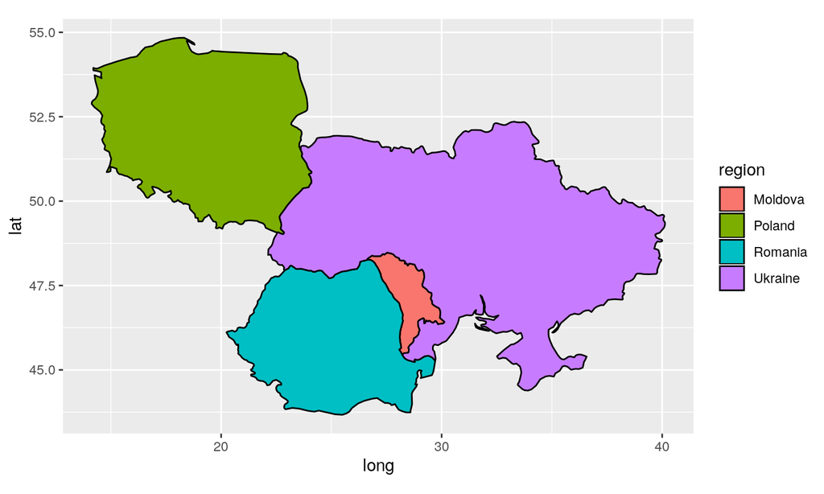

```r
east_europe <- map_data("world", region=c("Ukraine", "Poland", "Moldova", "Romania"))
ggplot(east_europe, aes(x=long, y=lat, group=group, fill=region)) +
geom_polygon(colour="black") +
coord_quickmap()
```

## Перехід в полярні координати

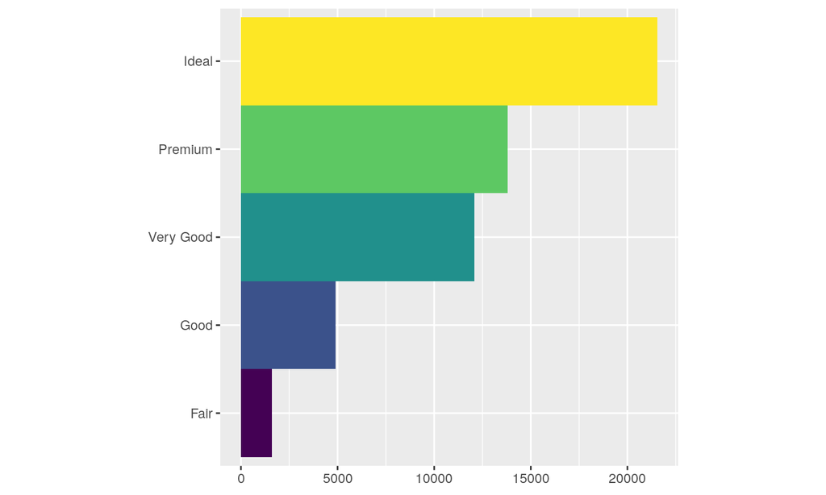

```r
bar <- ggplot(data = diamonds) +
geom_bar(
mapping = aes(x = cut, fill = cut),
show.legend = FALSE,
width = 1
) +
theme(aspect.ratio = 1) +
labs(x = NULL, y = NULL)
bar + coord_flip()
```

## Перехід

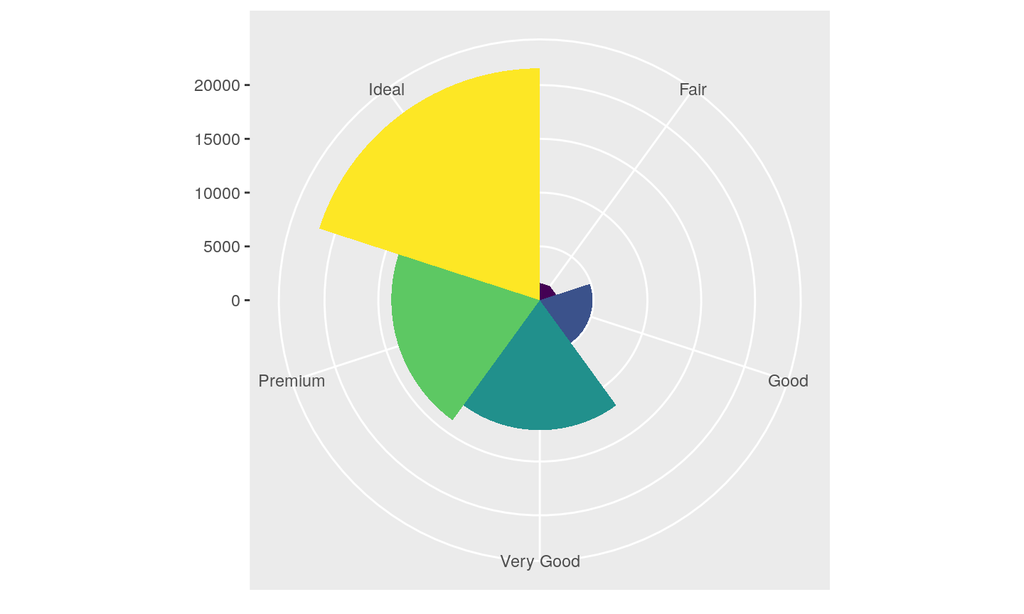

```r
bar + coord_polar()
```

## Невеликий адд-он

```r
library(gtrendsR)
t <- gtrends("НАУКМА", geo = "UA")
str(t)
```

```
## List of 7
##  $ interest_over_time :'data.frame': 260 obs. of  7 variables:
##   ..$ date    : POSIXct[1:260], format: "2014-10-05" ...
##   ..$ hits    : int [1:260] 26 53 28 29 44 32 38 37 26 27 ...
##   ..$ geo     : chr [1:260] "UA" "UA" "UA" "UA" ...
##   ..$ time    : chr [1:260] "today+5-y" "today+5-y" "today+5-y" "today+5-y" ...
##   ..$ keyword : chr [1:260] "НАУКМА" "НАУКМА" "НАУКМА" "НАУКМА" ...
##   ..$ gprop   : chr [1:260] "web" "web" "web" "web" ...
##   ..$ category: int [1:260] 0 0 0 0 0 0 0 0 0 0 ...
##  $ interest_by_country: NULL
##  $ interest_by_region :'data.frame': 27 obs. of  5 variables:
##   ..$ location: chr [1:27] "Kyiv city" "Kyivs'ka oblast" "Cherkas'ka oblast" "Vinnyts'ka oblast" ...
##   ..$ hits    : int [1:27] 100 46 21 19 16 13 11 7 6 6 ...
##   ..$ keyword : chr [1:27] "НАУКМА" "НАУКМА" "НАУКМА" "НАУКМА" ...
##   ..$ geo     : chr [1:27] "UA" "UA" "UA" "UA" ...
##   ..$ gprop   : chr [1:27] "web" "web" "web" "web" ...
##  $ interest_by_dma    : NULL
##  $ interest_by_city   :'data.frame': 1 obs. of  5 variables:
##   ..$ location: chr "Kiev"
##   ..$ hits    : int 100
##   ..$ keyword : chr "НАУКМА"
##   ..$ geo     : chr "UA"
##   ..$ gprop   : chr "web"
##  $ related_topics     :'data.frame': 41 obs. of  6 variables:
##   ..$ subject       : Factor w/ 14 levels "<1","1","10",..: 4 5 3 9 9 8 7 6 6 6 ...
##   ..$ related_topics: chr [1:41] "top" "top" "top" "top" ...
##   ..$ value         : chr [1:41] "National University Of Kyiv-Mohyla Academy, 1st Campus" "Library" "Naukova Biblioteka Natsionalʹnoho Universytetu \"Kyyevo-Mohylyansʹka Akademiya\"" "Academic department" ...
##   ..$ geo           : chr [1:41] "UA" "UA" "UA" "UA" ...
##   ..$ keyword       : chr [1:41] "НАУКМА" "НАУКМА" "НАУКМА" "НАУКМА" ...
##   ..$ category      : int [1:41] 0 0 0 0 0 0 0 0 0 0 ...
##   ..- attr(*, "reshapeLong")=List of 4
##   .. ..$ varying:List of 1
##   .. .. ..$ value: chr "top"
##   .. .. ..- attr(*, "v.names")= chr "value"
##   .. .. ..- attr(*, "times")= chr "top"
##   .. ..$ v.names: chr "value"
##   .. ..$ idvar  : chr "id"
##   .. ..$ timevar: chr "related_topics"
##  $ related_queries    :'data.frame': 18 obs. of  6 variables:
##   ..$ subject        : chr [1:18] "100" "41" "35" "29" ...
##   ..$ related_queries: chr [1:18] "top" "top" "top" "top" ...
##   ..$ value          : chr [1:18] "наукма бібліотека" "саз" "саз наукма" "наукма вступ" ...
##   ..$ geo            : chr [1:18] "UA" "UA" "UA" "UA" ...
##   ..$ keyword        : chr [1:18] "НАУКМА" "НАУКМА" "НАУКМА" "НАУКМА" ...
##   ..$ category       : int [1:18] 0 0 0 0 0 0 0 0 0 0 ...
##   ..- attr(*, "reshapeLong")=List of 4
##   .. ..$ varying:List of 1
##   .. .. ..$ value: chr "top"
##   .. .. ..- attr(*, "v.names")= chr "value"
##   .. .. ..- attr(*, "times")= chr "top"
##   .. ..$ v.names: chr "value"
##   .. ..$ idvar  : chr "id"
##   .. ..$ timevar: chr "related_queries"
##  - attr(*, "class")= chr [1:2] "gtrends" "list"
```

## Графік

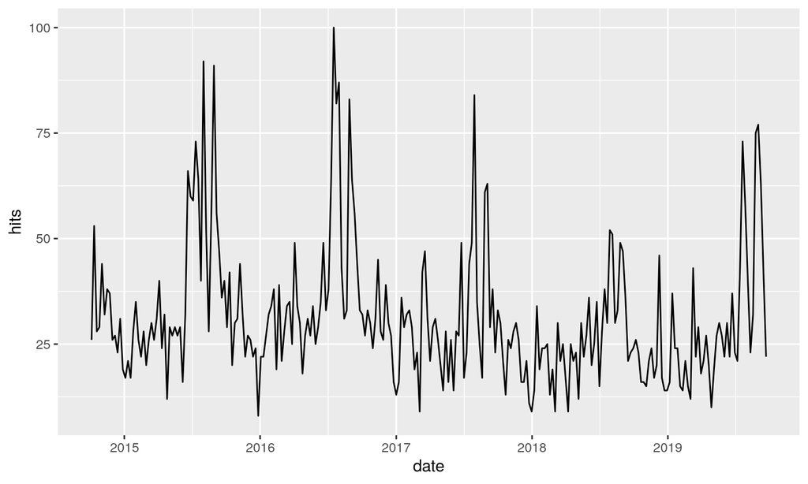

```r
s <- t$interest_over_time
ggplot(s,aes(date,hits)) + geom_line()
```